# Analysis of Prices

Floriano Peixoto

Here we are going to analyse the prices each competitor gives over time in a data set and discover what it has give us.

The data is described as bellow:

- PROD_ID: Product ID. the values varies between P1 to P9;
- DATE_EXTRACTION: Date and Time of the extraction of the competitors’ price, under YYYY-MM-DD HH:MM:SS format;
- COMPETITOR: Competitors’ ID (C1 to C6);
- COMPETITOR_PRICE: Competitors’ price per product, which can depend on the payment method;
- PAY_TYPE: Payment Method (1=deferred payment, 2=immediate payment)

```r
prices <-  read.csv("comp_prices.csv", sep=",", stringsAsFactors = T)
tail(prices)
```

|  | PROD_ID | DATE_EXTRACTION | COMPETITOR | COMPETITOR_PRICE | PAY_TYPE |
| --- | --- | --- | --- | --- | --- |
| 50109 | P5 | 2015-10-11 20:10:34 | C3 | 819.00 | 2 |
| 50110 | P5 | 2015-10-11 20:10:34 | C1 | 819.00 | 2 |
| 50111 | P5 | 2015-10-11 20:10:34 | C2 | 853.52 | 2 |
| 50112 | P5 | 2015-10-12 08:11:27 | C2 | 853.52 | 1 |
| 50113 | P5 | 2015-10-12 08:11:27 | C3 | 819.00 | 1 |
| 50114 | P5 | 2015-10-12 08:11:27 | C1 | 819.00 | 1 |

As the data documentation tells us the competitor is monitored twice a day.

```r
prices <- arrange(prices, COMPETITOR, PROD_ID, DATE_EXTRACTION)
tail(prices)
```

|  | PROD_ID | DATE_EXTRACTION | COMPETITOR | COMPETITOR_PRICE | PAY_TYPE |
| --- | --- | --- | --- | --- | --- |
| 50109 | P9 | 2015-10-14 08:11:39 | C6 | 39999.00 | 1 |
| 50110 | P9 | 2015-10-14 08:11:39 | C6 | 39999.00 | 2 |
| 50111 | P9 | 2015-10-14 20:10:24 | C6 | 399.99 | 1 |
| 50112 | P9 | 2015-10-14 20:10:24 | C6 | 399.99 | 2 |
| 50113 | P9 | 2015-10-14 20:11:30 | C6 | 399.99 | 1 |
| 50114 | P9 | 2015-10-14 20:11:30 | C6 | 399.99 | 2 |

Ordering the set by COMPETITOR, PROD_ID and DATE_EXTRACTION we can see that it´s true, we can turn that into a single line displaying it as min and max price.

```r
prices_min_max <- mutate(prices, YEAR = lubridate::year(DATE_EXTRACTION),
                            MONTH = lubridate::month(DATE_EXTRACTION),
                            DAY = lubridate::day(DATE_EXTRACTION),
                            PROD_ID = as.factor(PROD_ID)) %>%
                  group_by(COMPETITOR, PROD_ID, YEAR, MONTH, DAY) %>%
                  summarise(MIN_PRICE = min(COMPETITOR_PRICE),
                            MAX_PRICE = max(COMPETITOR_PRICE)) %>%
                  arrange(COMPETITOR, PROD_ID, YEAR, MONTH, DAY)
tail(prices_min_max)
```

| COMPETITOR | PROD_ID | YEAR | MONTH | DAY | MIN_PRICE | MAX_PRICE |
| --- | --- | --- | --- | --- | --- | --- |
| C6 | P9 | 2015 | 10 | 9 | 399.99 | 399.99 |
| C6 | P9 | 2015 | 10 | 10 | 399.99 | 399.99 |
| C6 | P9 | 2015 | 10 | 11 | 399.99 | 399.99 |
| C6 | P9 | 2015 | 10 | 12 | 399.99 | 399.99 |
| C6 | P9 | 2015 | 10 | 13 | 399.99 | 399.99 |
| C6 | P9 | 2015 | 10 | 14 | 399.99 | 39999.00 |

## Distribuition of products by competitor

With the data in our hands we can try to discrinate the presence of competitors in the market showing the products it sells.

```r
presence_market <- group_by(prices_min_max, COMPETITOR, PROD_ID) %>%
                   summarise(M = n())
tail(presence_market)
```

| COMPETITOR | PROD_ID | M |
| --- | --- | --- |
| C6 | P3 | 207 |
| C6 | P4 | 153 |
| C6 | P6 | 278 |
| C6 | P7 | 235 |
| C6 | P8 | 156 |
| C6 | P9 | 154 |

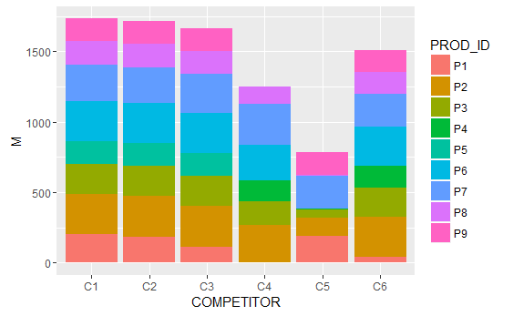

```r
g <- ggplot(presence_market, aes(y = M, x = COMPETITOR))
g +  geom_bar(stat = "identity", aes(fill = PROD_ID))
```

## The competitor with lowest price by product

With our data we can see now what are the competitors with the best price by product.

```r
competitor_best_price <- group_by(prices_min_max, PROD_ID, COMPETITOR) %>%
                         summarise(PRICE = min(MIN_PRICE)) %>%
                         slice(which.min(PRICE))
competitor_best_price
```

| PROD_ID | COMPETITOR | PRICE |
| --- | --- | --- |
| P1 | C1 | 1090.00 |
| P2 | C4 | 506.92 |
| P3 | C1 | 879.12 |
| P4 | C4 | 431.10 |
| P5 | C1 | 674.10 |
| P6 | C1 | 1225.97 |
| P7 | C1 | 588.71 |
| P8 | C1 | 359.10 |
| P9 | C1 | 359.10 |

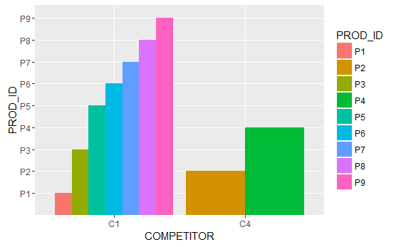

```r
g <- ggplot(competitor_best_price, aes(y = PROD_ID, x = COMPETITOR))
g +  geom_bar(stat = "identity", aes(fill = PROD_ID), position = "dodge")
```

The competitor C1 has the best prices for almost all products, loosing to C4 in just two products P2 and P4.

## The competitor with the highest prices

Now let´s see the competitor with the highest prices.

```r
competitor_worst_price <- group_by(prices_min_max, PROD_ID, COMPETITOR) %>%
                         summarise(PRICE = max(MAX_PRICE)) %>%
                         slice(which.max(PRICE))
competitor_worst_price
```

| PROD_ID | COMPETITOR | PRICE |
| --- | --- | --- |
| P1 | C1 | 149900 |
| P2 | C4 | 79900 |
| P3 | C1 | 119900 |
| P4 | C6 | 49700 |
| P5 | C2 | 84890 |
| P6 | C6 | 149900 |
| P7 | C3 | 104900 |
| P8 | C6 | 39999 |
| P9 | C5 | 56900 |

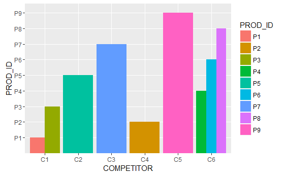

```r
g <- ggplot(competitor_worst_price, aes(y = PROD_ID, x = COMPETITOR))
g +  geom_bar(stat = "identity", aes(fill = PROD_ID), position = "dodge")
```

Diferently from the lowest prices, we can see a better distribuition over the competitors.

## The lowest and higher prices per competitor by product

It´s intereting to compare the prices each competitor has, historically, for each product in terms to understand more about their behaviors during the year.

```r
comp_best_worst_pric_prod <- group_by(prices_min_max, COMPETITOR, PROD_ID) %>%
                             summarise(MIN_PRICE = min(MIN_PRICE),
                                       MAX_PRICE = max(MAX_PRICE)) %>%
                             arrange(COMPETITOR, PROD_ID)
comp_best_worst_pric_prod
```

| COMPETITOR | PROD_ID | MIN_PRICE | MAX_PRICE |
| --- | --- | --- | --- |
| C1 | P1 | 1090.00 | 149900.0 |
| C1 | P2 | 539.10 | 72498.0 |
| C1 | P3 | 879.12 | 119900.0 |
| C1 | P5 | 674.10 | 81900.0 |
| C1 | P6 | 1225.97 | 148000.0 |
| C1 | P7 | 588.71 | 84090.0 |
| C1 | P8 | 359.10 | 39300.0 |
| C1 | P9 | 359.10 | 39300.0 |
| C2 | P1 | 1099.00 | 149900.0 |
| C2 | P2 | 539.10 | 72498.0 |

[output cut: 36 more lines]

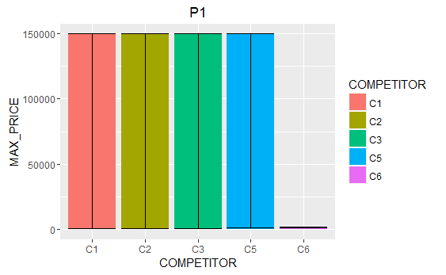

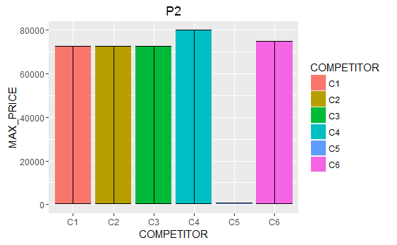

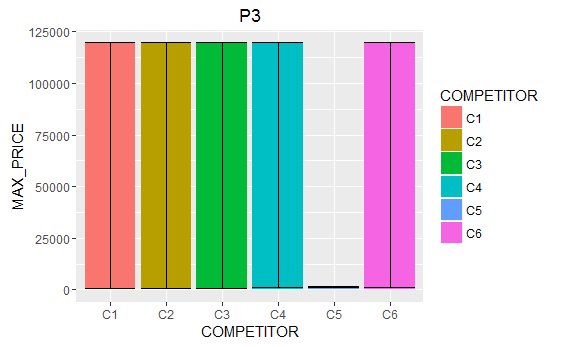

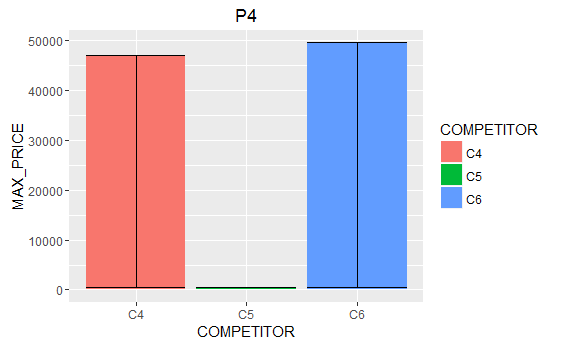

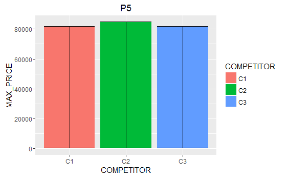

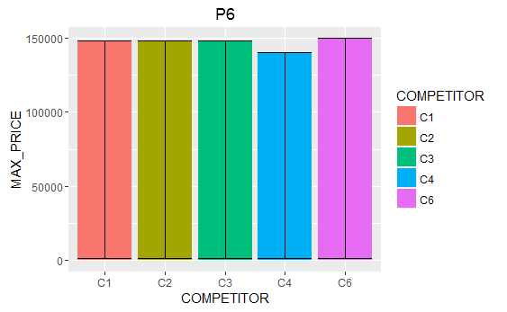

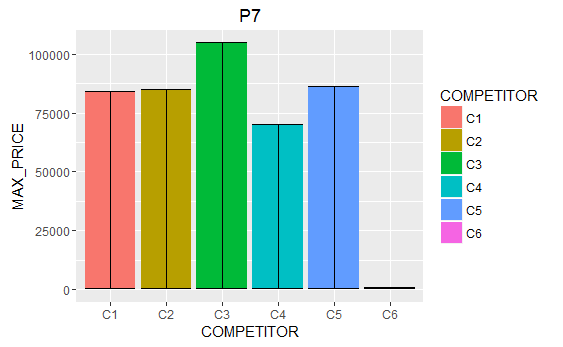

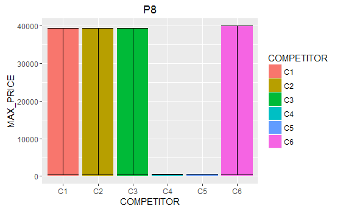

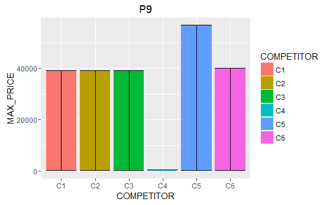

```r
for(product in levels(comp_best_worst_pric_prod$PROD_ID)){

  g <- ggplot(filter(comp_best_worst_pric_prod, PROD_ID == product), aes(y = MAX_PRICE, x = COMPETITOR, ymin = MIN_PRICE, ymax = MAX_PRICE, fill = COMPETITOR))

  g <- g +  geom_bar(stat = "identity") +
  geom_errorbar()   +
  ggtitle(product)

  print(g)
}
```

As we can see some competitors have similar prices for some products, but others have a really lower costs. And as we could see before not all of them sell all products, so some of them has higher presence in the market.